# Statistics 744, McMaster University

# spatial examples

Alex Bushby, Aleks Jovic, Ben Bolker

## pkgs

```
library(ggmap)
library(tidyverse)
library(viridis)
library(sf)
library(geogrid)

## Warning in fun(libname, pkgname): rgeos: versions of GEOS runtime 3.9.0-CAPI-1.16.2
## and GEOS at installation 3.8.1-CAPI-1.13.3differ

library(gganimate)
library(RColorBrewer)
library(htmlwidgets)
if (!require(transformr,quietly=TRUE)) {
  warning("animation example might not work; ",
          "consider running ",
          "'remotes::install_github(\"thomasp85/transformr'\")")
}
library(leaflet)
load("tdata/googlemaps.rda")
```

## crime

The `crime` dataset contains crime reports for Houston from January-August 2010, geocoded with Google Maps.

```
tibble(crime)

## # A tibble: 86,314 × 17
##    time                date      hour premise offense  beat  block  street type
##    <dttm>              <chr>    <int> <chr>   <fct>    <chr> <chr>  <chr>  <chr>
##  1 2010-01-01 01:00:00 1/1/2010     0 18A     murder   15E30 9600-… marli… "ln"
##  2 2010-01-01 01:00:00 1/1/2010     0 13R     robbery  13D10 4700-… telep… "rd"
##  3 2010-01-01 01:00:00 1/1/2010     0 20R     aggrava… 16E20 5000-… wickv… "ln"
##  4 2010-01-01 01:00:00 1/1/2010     0 20R     aggrava… 2A30  1000-… ashla… "st"
##  5 2010-01-01 01:00:00 1/1/2010     0 20A     aggrava… 14D20 8300-… canyon ""
##  6 2010-01-01 01:00:00 1/1/2010     0 20R     burglary 18F60 9300-… rowan  "ln"
##  7 2010-01-01 01:00:00 1/1/2010     0 20A     burglary 10H60 2500-… south… "blv…
##  8 2010-01-01 01:00:00 1/1/2010     0 20R     burglary 13D10 6300-… rupley "cir"
##  9 2010-01-01 01:00:00 1/1/2010     0 20A     burglary 3B10  5000-… georgi "ln"
## 10 2010-01-01 01:00:00 1/1/2010     0 20P     burglary 20G20 10700… briar… "dr"
## # … with 86,304 more rows, and 8 more variables: suffix <chr>, number <int>,
## #   month <ord>, day <ord>, location <chr>, address <chr>, lon <dbl>, lat <dbl>
```

Lots of useful info: dates, types of crimes, locations by type of place, locations by street, locations by longitude/latitude …

First, let’s get an overview of the crimes on the map. The `qmplot` is often recommended as a quick way to do mapping (but we will switch to another approach shortly). We put in longitude (`lon`) and latitude (`lat`) for the `x` and `y` parameters and specify `crime` as the data set. This plots all of the crimes in the database. (Note that to specify colour, size, etc. as set values, we need to use `I()` rather than including them outside of the mapping (`aes()`) as in normal `ggplot` usage.)

(Example adapted from [here](https://github.com/tidyverse/ggplot2/wiki/crime-in-downtown-houston,-texas-:-combining-ggplot2-and-google-maps).)

```
## remotes::install_github("bbolker/ggmap")
q1 <- qmplot(lon, lat, data = crime,
             maptype = "toner-lite",
             ## for q* plots need to use I() for direct specifications
             colour = I("red"),
             size = I(0.9),
             alpha=I(.3))
```

A slightly slower but safer method is to get the map first, then combine it with the data. This way we can retrieve the map and store it; this is both more efficient if we’re going to make a bunch of plots with the same map (almost inevitable if we’re polishing a data visualization), and safer (in case the server goes down/network connection is lost/etc.).

```
## utility function: extract appropriate components for retrieving a Stamen/OSM map
get_mapzone <- function(data, latcol="lat", loncol="lon") {
  lon <- na.omit(data[[loncol]])
  lat <- na.omit(data[[latcol]])
  return(c(left=min(lon),right=max(lon),bottom=min(lat),top=max(lat)))
}
houston_mz <- get_mapzone(crime) ## find boundaries
## retrieve map
houston_map1 <- get_stamenmap(houston_mz,zoom=7, maptype="toner-lite",
                              messaging=FALSE)
```

Now we can combine the map with the data set:

```
(ggmap(houston_map1)
  + geom_point(data=crime,colour="red",size=0.9,alpha=0.3)
)
```

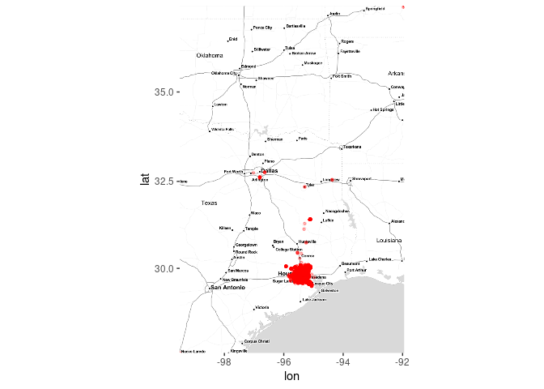

This graph is not very good, in particular because of the few crimes that are reported far away from the city but still end up in the database.

Reduce crime to violent crimes in downtown Houston:

```
violent_crime <-
  (crime
    %>% filter(
          !offense %in% c("auto theft", "theft", "burglary"),
          -95.39681 <= lon & lon <= -95.34188,
          29.73631 <= lat & lat <=  29.78400
        )
    %>% mutate(
          ## drops unused levels, mitigates downstream errors
          offense = fct_drop(offense),
          offense = fct_relevel(offense,
               c("robbery", "aggravated assault", "rape", "murder")
               )
        )
  )

houston_map2 <- get_stamenmap(get_mapzone(violent_crime), maptype="toner-lite",
                                zoom=14,messaging=FALSE)
(ggmap(houston_map2)
  + geom_point(data = violent_crime, colour = "red",size = 0.9, alpha=.3)
)
```

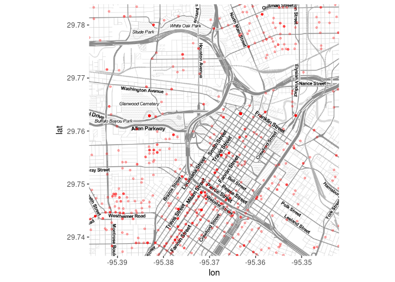

Re-use the map, plotting as density contours instead (i.e., transform the points to a density field, then summarize the density field as a set of contours)

```
(ggmap(houston_map2)
  + geom_density2d(data = violent_crime, aes(x=lon,y=lat), col="red")
)
```

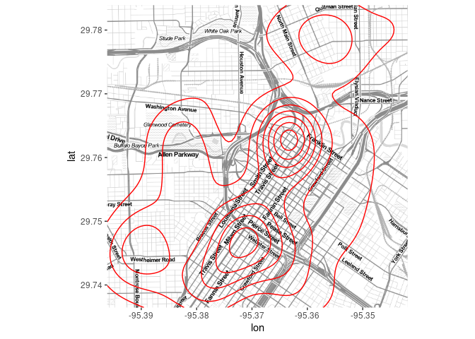

Or do 2-D (square) binning, with a custom gradient (and log-scaled breaks):

```
(ggmap(houston_map2)
  + geom_bin2d(data = violent_crime, alpha=0.5)
  + scale_fill_gradient(low="#F0F0FF", high="#131393",
                        trans=scales::log10_trans())
)

## Warning: Removed 7 rows containing missing values (geom_tile).
```

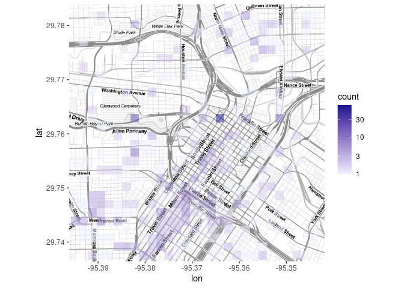

## Heatmap

To make the contour map more useful, we can assign a gradient (using a “polygon” rather than a “density_2d” geom with `stat_density_2d`) . Let’s look at the robberies:

```
houston_map3 <- get_stamenmap(get_mapzone(violent_crime),
                              maptype="toner-background",
                              zoom=14, messaging=FALSE)

robbery <- violent_crime %>% filter(offense=='robbery')
(vc5 <- ggmap(houston_map3)
  + stat_density_2d(data=robbery,
                    aes(fill = ..level..), geom = "polygon",
                    alpha = .35, colour = NA)
  + scale_fill_gradient2("Robbery\nheatmap",
                         low = "white", mid = "yellow",
                         high = "red", midpoint = 650)
)
```

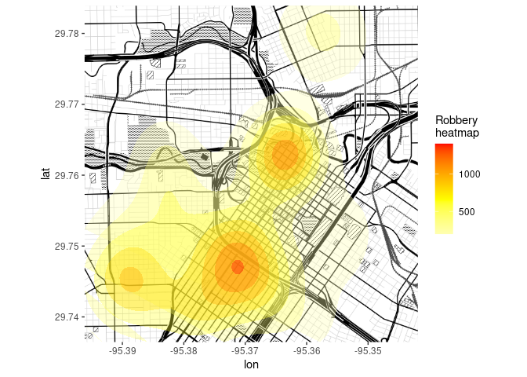

We can do all the other `ggplot` stuff, like faceting:

```
(ggmap(houston_map3,darken=c(0.9,"white")) ## fade map layer
  + geom_point(data = violent_crime, aes(colour = offense, size=offense))
  + facet_wrap(~ offense)
  + scale_colour_brewer(palette="Dark2")
  + scale_size_manual(values=c(1,1,2,3)) ## adjust point sizes for visibility
  + theme(legend.position="none")
)
```

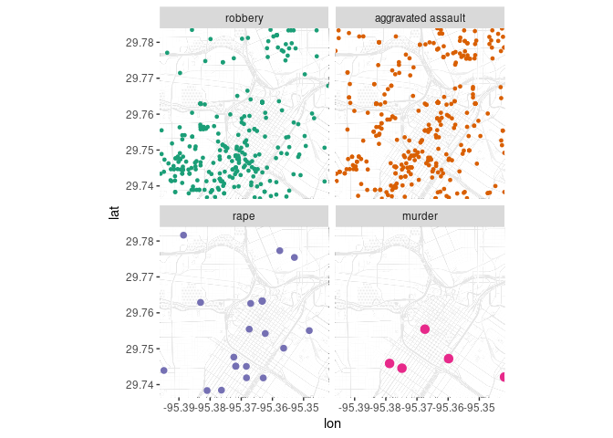

```
hm <- ggmap(houston_map3, base_layer = ggplot(aes(x = lon, y = lat),
                                              data = violent_crime),
            darken=c(0.9,"white"))
(hm
  + stat_density2d(aes(fill = ..level.., alpha = ..level..),
                bins = 5, geom = "polygon")
  + scale_fill_gradient(low = "black", high = "red")
  + facet_wrap(~ day)
  + theme(legend.position="none")
)
```

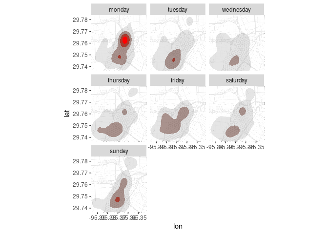

(there are some contouring artifacts here I don’t understand …)

This is pretty but maybe not useful …

```
(hm
  + stat_density2d(aes(x = lon, y = lat, fill = offense, alpha = ..level..),
                   bins = 5, geom = "polygon")
  + scale_fill_brewer(palette = "Dark2")
)
```

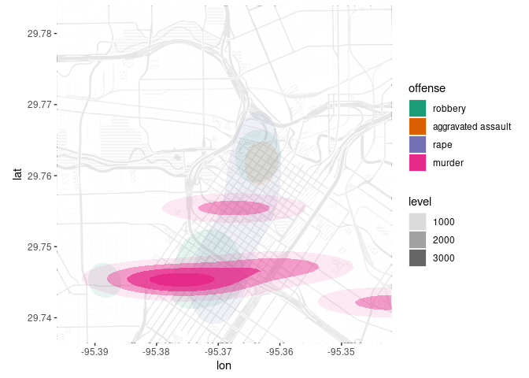

There is not a super-easy way to code scales (we’d like 29.75 to be 29<sup>∘</sup>45′*N*, e.g. see [here](https://stackoverflow.com/questions/33302424/format-latitude-and-longitude-axis-labels-in-ggplot) for a partial solution), but maybe we don’t even need them on a map?

# Canadian electoral ridings

From [this github site](https://github.com/paleolimbot/blogdown-site/tree/master/content/post/2019-10-21-ridings):

The riding boundaries come in shapefile format, which is handled by a one-liner to `read_sf()`. I’m going to simplify the boundaries a bit to speed up the plotting time. The `dTolerance` argument is in map units, and it took some experimenting to settle on the number 100.

```
ridings <- (read_sf("tdata/boundaries_2015_shp_en/FED_CA_2_2_ENG.shp")
  %>% st_simplify(dTolerance = 100)
)

(ggplot(ridings)
  + geom_sf(aes(fill = PROVCODE))
  + theme_void()
)
```

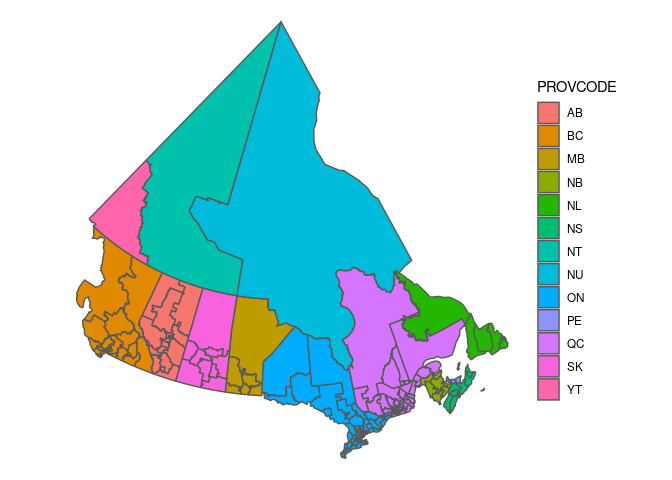

```
fn <- "../data/ridings_hex.rds"
if (file.exists(fn)) {
  ridings_hex <- read_rds(fn)
} else {
  cat("SLOW computation coming up!\n")
  print(system.time({
    ridings_grid <- ridings %>%
      calculate_grid(grid_type = "hexagonal", seed = 1938)
    ridings_hex <- assign_polygons(ridings, ridings_grid)
    write_rds(ridings_hex, fn)
  }))
}
```

```
fix_fun <- function(x, label) {
  (x
    %>% st_set_crs(NA)
    %>% dplyr::select(PROVCODE,geometry)
    %>% mutate(type=label)
  )
}
ridings_list <- list(geographic=ridings, hex=ridings_hex)
## purrr:::map(ridings_list,st_crs)
ridings_combined <- purrr::map2(ridings_list, names(ridings_list), fix_fun)
## dplyr::bind_rows doesn't work: https://github.com/tidyverse/dplyr/issues/2457
ridings_combined <- do.call(rbind, ridings_combined)

rplot <- ggplot(ridings_combined) +
  geom_sf(aes(fill = PROVCODE)) +
  theme_void()
rplot+ facet_wrap(~type)
```

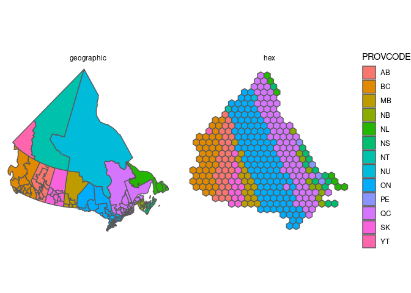

[output not shown]

[output cut: 21 more lines]

[output not shown]

[figure not shown]

## dog licenses

NYC zip codes [here](https://data.cityofnewyork.us/widgets/i8iw-xf4u)

Process data:

```
zc <- read_sf("tdata/nyc_zipcodes")
Sys.setenv("VROOM_CONNECTION_SIZE" = 2^30)
dogs <- (data.table::fread("../data/NYC_dogs.csv.gz")
  %>% as_tibble()
  %>% rename(zipcode = "Owner Zip Code",
             name = "Animal Name",
             gender = "Animal Gender",
             breed_1 = "Primary Breed",
             color = "Animal Dominant Color")
  %>% mutate(across(zipcode, ~ sprintf("%05d", .))) ## zero-pad
  %>% select(zipcode, name, gender, breed_1, color)
)
z_rottie <- (dogs
  %>% group_by(zipcode)
  %>% summarise(tot = sum(stringr::str_detect(breed_1,"[Rr]ott")),
                tot_dogs = n(),
                frac = tot / n())
)
## join in this order so we end up with an sf object
z_dogs  <- full_join(zc, z_rottie, by = c("ZIPCODE" = "zipcode"))

dog_map1 <- (ggplot(z_dogs)
  + geom_sf(aes(fill = frac, alpha = tot_dogs, geometry = geometry))
  + theme_void()
  + scale_fill_gradient(low="white",high="brown",
                        trans=scales::logit_trans(),
                        breaks=c(0.01,0.05,0.1))
  + scale_alpha(range = c(0.9, 1), guide = "none")
)
print(dog_map1)
```

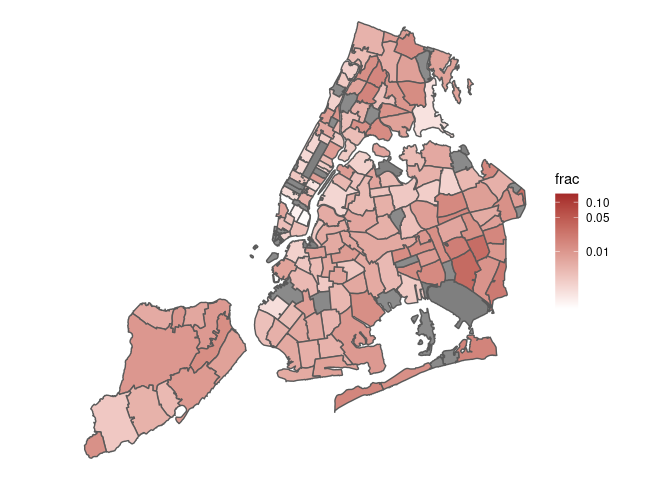

- superimpose on a map, possibly clipped?

## leaflet

- super-easy to generate maps
- adding points etc.
- choropleth example: https://rstudio.github.io/leaflet/choropleths.html
- John Snow cholera example: https://freakonometrics.hypotheses.org/19473

Quick Houston-crime example:

```
## predefine colour palette
bp <- brewer.pal(name="Dark2",n=length(levels(violent_crime$offense)))
L1 <- (leaflet(data=st_as_sf(violent_crime, coords=c("lon","lat")))
  %>% setView(-95.35,29.75,zoom=13)
  %>%
  ## use Stamen/toner rather than default Open Street Maps tiles
  addProviderTiles(providers$Stamen.Toner,
                   options = providerTileOptions(opacity = 0.35))
  %>% addCircleMarkers(radius=5,weight=2,
                       color=~bp[offense],
                       popup=~date)
)
saveWidget(L1,file="houston_leaflet.html")
```

embedding info [here](https://stackoverflow.com/questions/42008179/embed-r-leaflet-map-in-wordpress):

[interactive chart not shown]

Dogs: couldn’t get this working in the end …

```
(simplevis::leaflet_sf(z_dogs)
  %>% setView(-74,40.75,zoom=11)
  %>% addPolygons(data = z_dogs2,
                  popup = ~frac,
                  fill = ~ frac,
                  fillColor = colorRamp(c("white", "brown")))
  )
```

## additional challenges

- ggplot is to ggplotly as ggmap is to (???) + leaflet (see cholera example)
- syncing various layers (lat/lon to ????)
- transforming *irregular* points with continuous values
  - `akima`
  - kriging? Gaussian processes?
  - fit surface with `mgcv` package then overlay?
- multivariate/compositional responses: `scatterpie` package. (Mini-bars?)

Course home page